# Dublin Data Science Workshop on Survival Analysis

### 4.5.4 Residual Plots

Much like for linear models, these residuals are useful to help decide which variables may have predictive power in our survival model. We do this by plotting the values of the residual against the variable values.

To do this, we first add the residuals to the original dataset so that we can construct some of the residual plots.

```r
telco_null_assess_tbl <- telco_churn_tbl %>%
    mutate(resid_m = telco_model00_resid_m
          ,resid_d = telco_model00_resid_d
           )
```

Now that we have put the table together we can construct some two-way plots of the variable against the martingale residual:

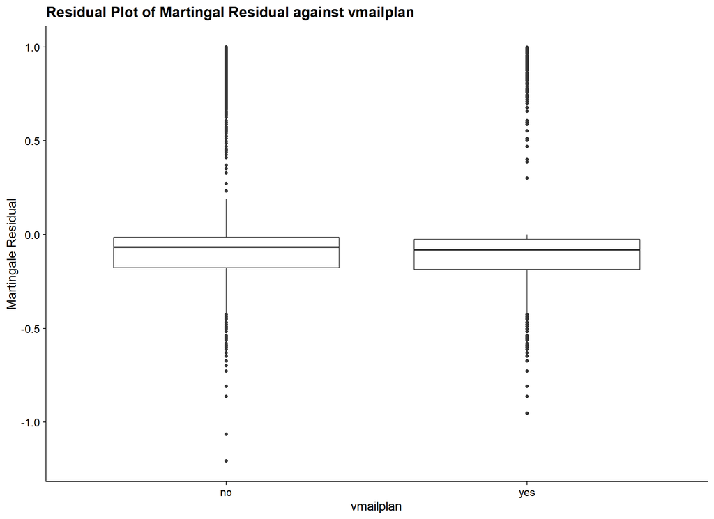

```r
ggplot(telco_null_assess_tbl) +
    geom_boxplot(aes(x = vmailplan, y = resid_m)) +
    xlab('vmailplan') +
    ylab('Martingale Residual') +
    ggtitle('Residual Plot of Martingal Residual against vmailplan')
```

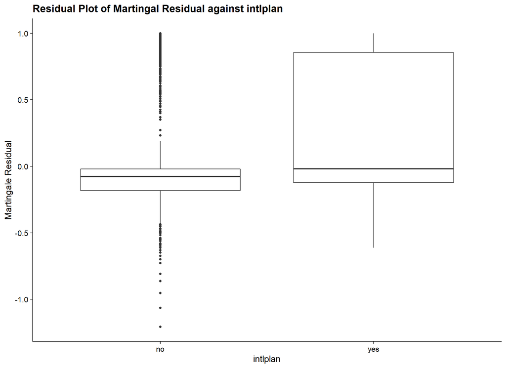

```r
ggplot(telco_null_assess_tbl) +
    geom_boxplot(aes(x = intlplan, y = resid_m)) +
    xlab('intlplan') +
    ylab('Martingale Residual') +
    ggtitle('Residual Plot of Martingal Residual against intlplan')
```

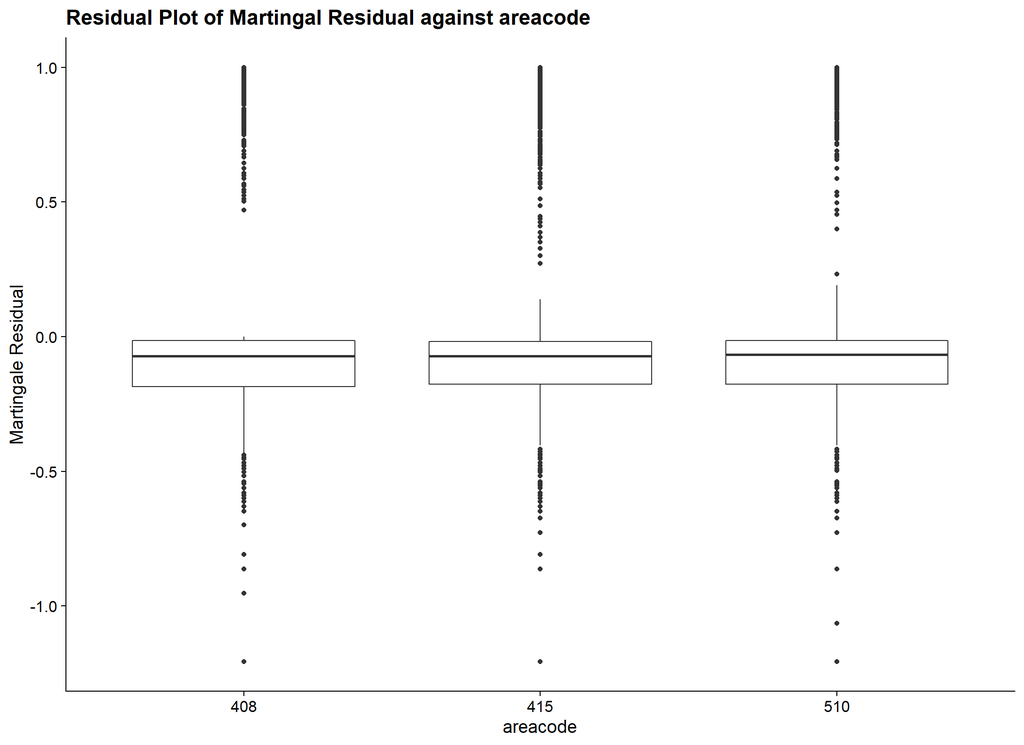

```r
ggplot(telco_null_assess_tbl) +
    geom_boxplot(aes(x = areacode, y = resid_m)) +
    xlab('areacode') +
    ylab('Martingale Residual') +
    ggtitle('Residual Plot of Martingal Residual against areacode')
```

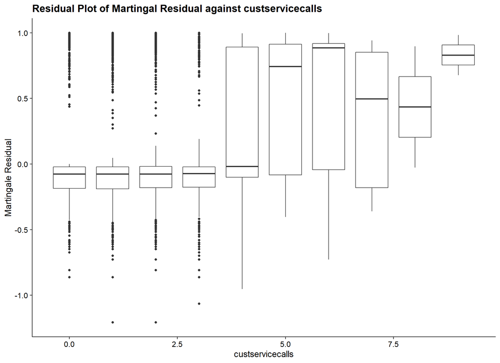

```r
ggplot(telco_null_assess_tbl) +
    geom_boxplot(aes(x = custservicecalls, y = resid_m, group = custservicecalls)) +
    xlab('custservicecalls') +
    ylab('Martingale Residual') +
    ggtitle('Residual Plot of Martingal Residual against custservicecalls')
```

`custservicecalls` is a numeric variable, but it does not take many values so we can create boxplots rather than a more typical scatterplot.

For continuous variables, we look at those scatterplots:

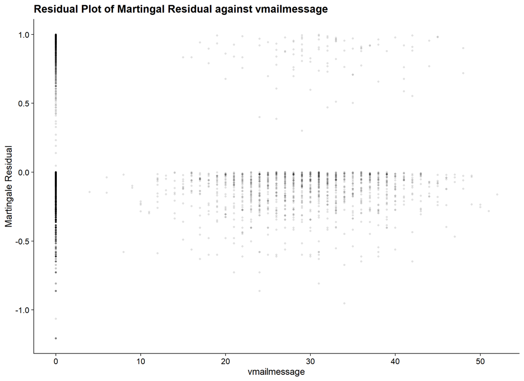

```r
ggplot(telco_null_assess_tbl) +
    geom_point(aes(x = vmailmessage, y = resid_m), size = 1, alpha = 0.1) +
    xlab('vmailmessage') +
    ylab('Martingale Residual') +
    ggtitle('Residual Plot of Martingal Residual against vmailmessage')
```

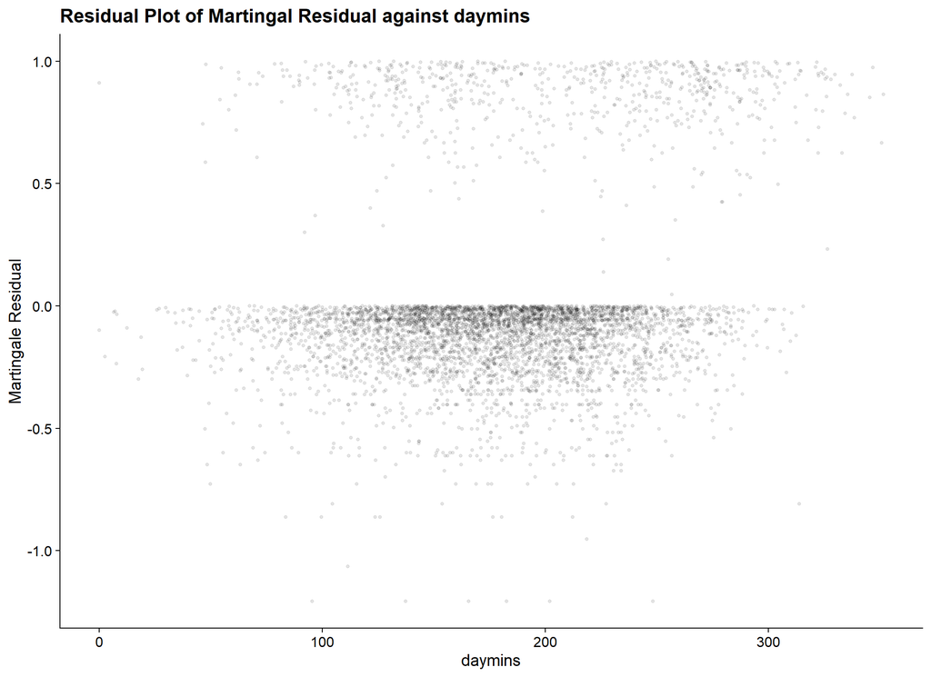

```r
ggplot(telco_null_assess_tbl) +
    geom_point(aes(x = daymins, y = resid_m), size = 1, alpha = 0.1) +
    xlab('daymins') +
    ylab('Martingale Residual') +
    ggtitle('Residual Plot of Martingal Residual against daymins')
```

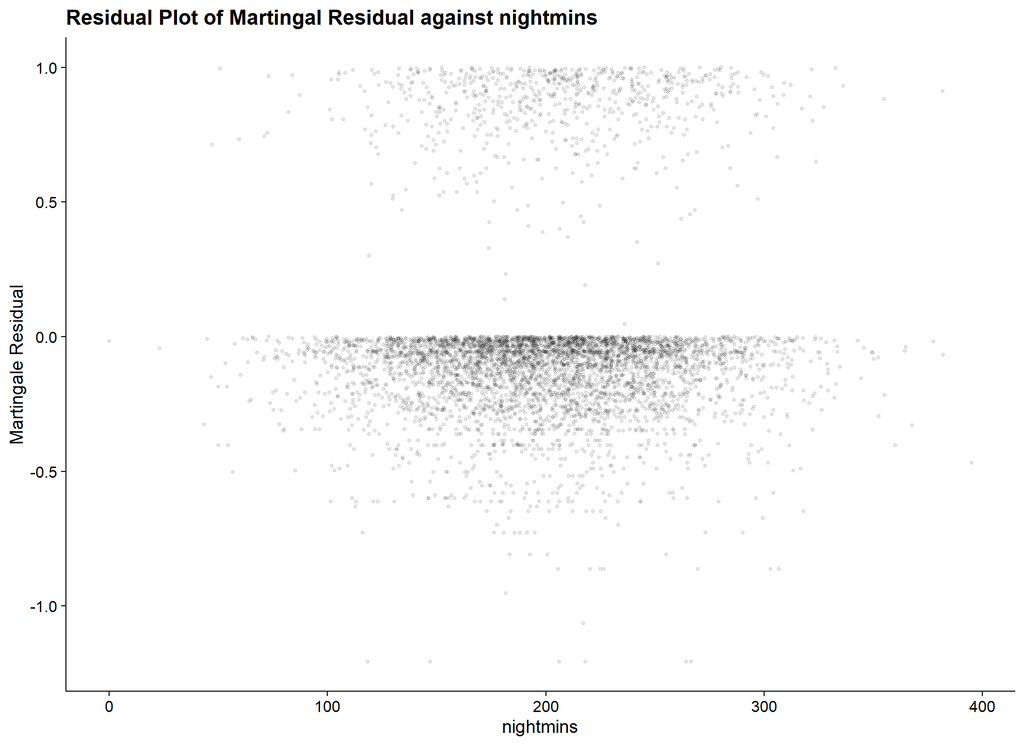

```r
ggplot(telco_null_assess_tbl) +
    geom_point(aes(x = nightmins, y = resid_m), size = 1, alpha = 0.1) +
    xlab('nightmins') +
    ylab('Martingale Residual') +
    ggtitle('Residual Plot of Martingal Residual against nightmins')
```

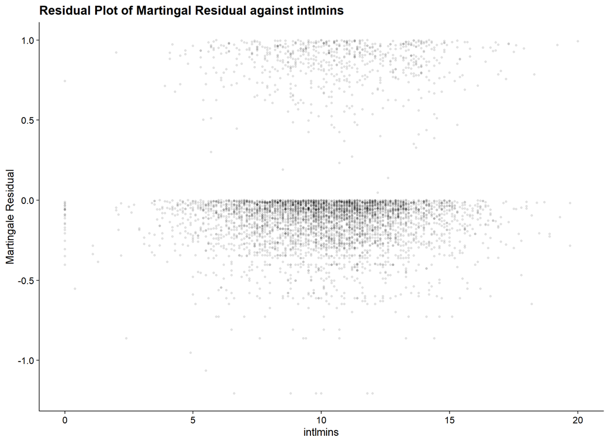

```r
ggplot(telco_null_assess_tbl) +
    geom_point(aes(x = intlmins, y = resid_m), size = 1, alpha = 0.1) +
    xlab('intlmins') +
    ylab('Martingale Residual') +
    ggtitle('Residual Plot of Martingal Residual against intlmins')
```

No strong patterns stand out here, but that does not necessarily rule them out of candidate models. We will not know the predictive power till we try them in a model.

## 4.6 Assessing the Proportional Hazards Assumption

The proportional hazards assumption is key in the construction of the partial likelihood, as it allows the cancellation of the baseline hazard in the calculations.

This assumption of proportional hazards is likely to be violated in practice, so the question is how big the effect those violations have on our model. Formal statistical tests are thus of limited value, but can be a useful indicator of issues with any models built.

### 4.6.1 Residual Plots

Tests for the proportional hazards assumption reduce to checking if the parameters from the model are constant over time. This task is made easier by the construction of ‘Schoenfeld’ residuals, which we will not discuss here, but are easily calculated in R by using the `cox.zph()` function.

```r
telco_model01_coxzph <- telco_model01_coxph %>% cox.zph(transform = 'km')

telco_model01_coxzph %>% print()
```

```
##                 rho chisq     p
## vmailplanyes 0.0597  2.52 0.112
```

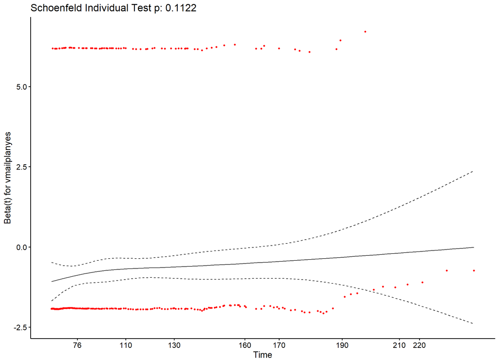

```r
telco_model01_coxzph %>% ggcoxzph()
```

The plot and $p$-value suggest the assumptions are not horrible here.

We now move on to the second model we built.

```r
telco_model02_coxzph <- telco_model02_coxph %>% cox.zph(transform = 'km')

telco_model02_coxzph %>% print()
```

```
##                rho chisq     p
## intlplanyes 0.0269 0.512 0.474
```

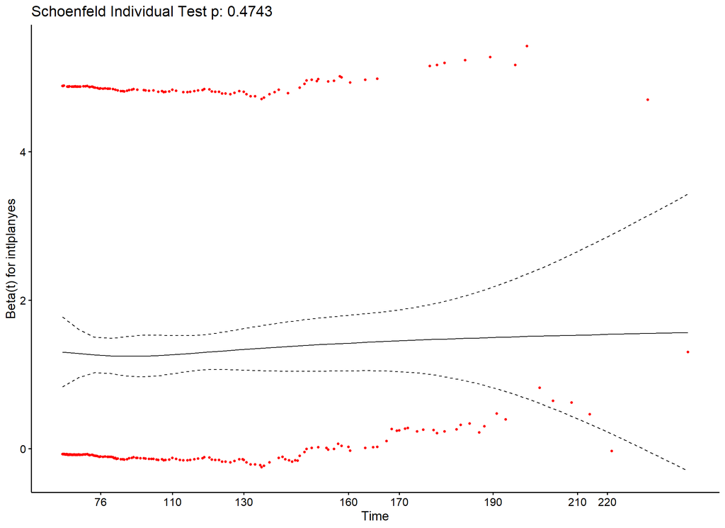

```r
telco_model02_coxzph %>% ggcoxzph()
```

The assumption also seems sound here.

We now try the combined model, `model03`:

```r
telco_model03_coxzph <- telco_model03_coxph %>% cox.zph(transform = 'km')

telco_model03_coxzph %>% print()
```

```
##                 rho chisq     p
## vmailplanyes 0.0547 2.100 0.147
## intlplanyes  0.0298 0.626 0.429
## GLOBAL           NA 2.780 0.249
```

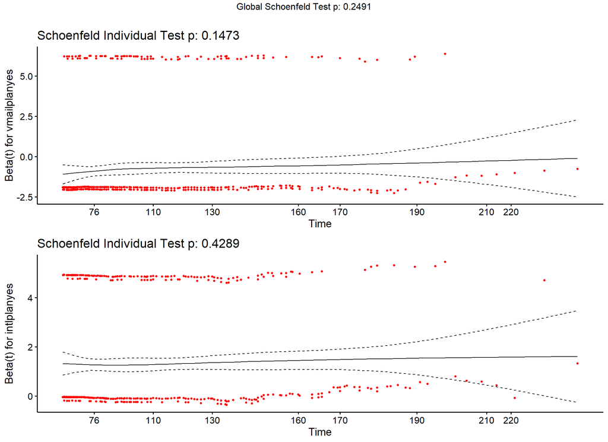

```r
telco_model03_coxzph %>% ggcoxzph()
```